# Predicting Excessive Enforcement Patterns in Police Behavior After Vehicles Stops in New York

### Reported Sex

```r
ratio_by_cat(
  vehstops, arrested, sex,
  "Reported sex", "Arrest Rate (%)", "Arrest Ratio by Reported sex for 2-Wheels Vehicles Stopped in NYC",
  style = "stack", legend_title = "Stop ended in arrest?", target_labels = c("No", "Yes"),
  subtitle = "Male drivers are subject to higher arrest rates, followed by Unknown category",
)
```

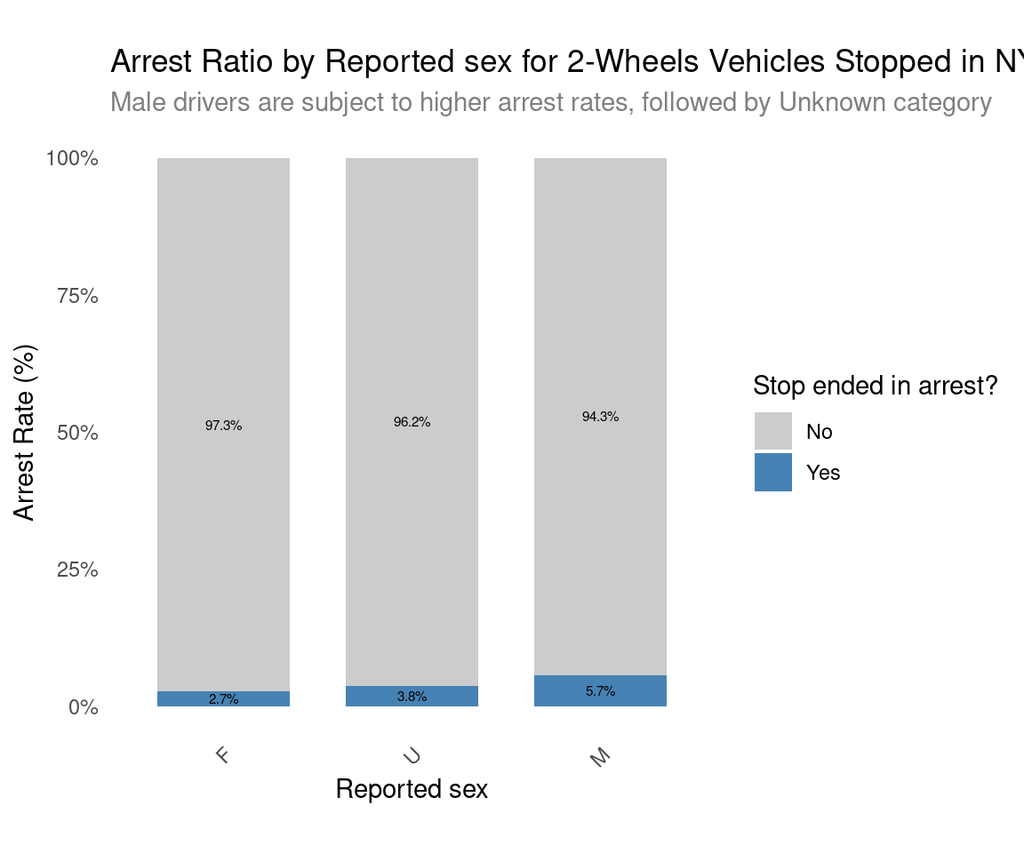

```r
vehstops %>%
  group_by(sex, arrested) %>%
  summarise(count = n(), .groups = "drop_last") %>%
  mutate(percentage = count / sum(count))
```

```
## # A tibble: 6 × 4
## # Groups:   sex [3]
##   sex   arrested  count percentage
##   <chr>    <int>  <int>      <dbl>
## 1 F            0   6840     0.973
## 2 F            1    191     0.0272
## 3 M            0 171177     0.943
## 4 M            1  10331     0.0569
## 5 U            0    965     0.962
## 6 U            1     38     0.0379
```

What can we say?

- **Key finding**: This highlights a clear disparity in arrest rates across reported sex categories for two-wheels vehicle stops. Female drivers (`F`) experience the lowest arrest rate at $2.7\%$ ($191$ arrests), followed by the unknown or unrecorded category (`U`) at $3.8\%$ (with just $38$ arrests). Male drivers (`M`) are subject to the highest rate, with $5.7\%$ of their total stops resulting in an arrest. In fact, the total Male drivers arrests are $10331$.
- **Interpretation**: The ratio of arrest, given a stop, **is more than twice as high for male drivers compared to female** drivers. This variation affects our current analysis by suggesting that reported sex is another key predictor that needs to be included in our statistical models.
- **Comment**: The higher arrest rate among male drivers might align with the broader demographic trends in traffic violations, where they are associated with risky driving behaviors. Interestingly, the Unknown category is not even, suggesting that incomplete data entry might be randomly distributed or slightly skewed toward cases that did not escalate to a full arrest.
- **Proposed Action**: We will try to understand the importance of this component, because the low association with the target and the imbalance nature of this feature may become tricky in the modeling phase.

### Reported Ethnicity

```r
ratio_by_cat(
  vehstops, arrested, ethnicity,
  "Reported ethnicity", "Arrest Rate (%)", "Escalation ratio by Reported Ethnicity for 2-Wheels Vehicles Stopped in NYC",
  style = "stack", legend_title = "Stop ended in arrest?", target_labels = c("No", "Yes"),
  subtitle = "Hispanic and Black Motorists have the highest arrest rates and account for most arrests",
)
```

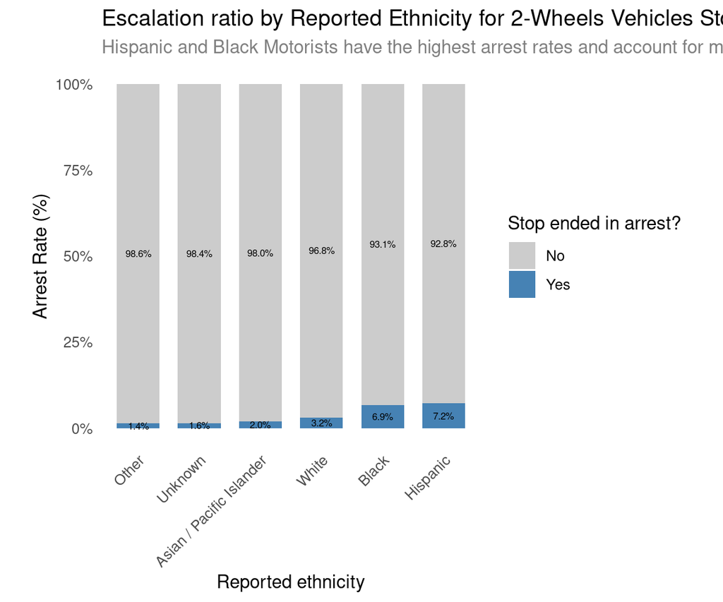

```r
vehstops %>%
  group_by(ethnicity, arrested) %>%
  summarise(count = n(), .groups = "drop_last") %>%
  mutate(percentage = count / sum(count))
```

```
## # A tibble: 12 × 4
## # Groups:   ethnicity [6]
##    ethnicity                arrested count percentage
##    <chr>                       <int> <int>      <dbl>
##  1 Asian / Pacific Islander        0 20388     0.980
##  2 Asian / Pacific Islander        1   420     0.0202
##  3 Black                           0 36444     0.931
##  4 Black                           1  2686     0.0686
##  5 Hispanic                        0 83717     0.928
##  6 Hispanic                        1  6533     0.0724
##  7 Other                           0  3119     0.986
##  8 Other                           1    45     0.0142
##  9 Unknown                         0 17417     0.984
## 10 Unknown                         1   279     0.0158
## 11 White                           0 17897     0.968
## 12 White                           1   597     0.0323
```

What can we say?

- **Key finding**: Hispanic motorists represent the largest slice with $90,250$ total stops and the highest absolute number of arrests at $6,533$ ($7.24\%$). Black motorists experience the second-highest escalation rate with $2,686$ arrests out of $39,130$ stops ($6.86\%$). In contrast, White motorists account for $18,494$ stops and $597$ arrests ($3.23\%$). Finally, Asian / Pacific Islander, Other, and Unknown categories maintain the lowest arrest rates, all remaining near or below $2.0\%$.
- **Interpretation**: The probability of a stop resulting in an arrest is more than twice as high for Black and Hispanic motorists compared to White motorists. The rates are calculated from a large sample, indicating they are highly stable and unlikely to be the result of small-sample variance.
- **Proposed Action**: This imbalance indicates that reported ethnicity is a critical factor that must be included in our models.

# Final touches

## Re-Ordering Features

We re-order the features for better display

```r
vehstops_ord <- vehstops %>%
  select(
    year, month, hot_season, weekday,
    hour, time_bracket,
    area, boro,
    sex, ethnicity,
    age, age_bracket,
    arrested
  )
```

Here is the final version.

```r
print(dfSummary(vehstops_ord), method="render")
```

Data Frame Summary

vehstops_ord

**Dimensions**: 189542 x 13  
**Duplicates**: 11293

| **No** | **Variable** | **Stats / Values** | **Freqs (% of Valid)** | **Graph** | **Valid** | **Missing** |
| --- | --- | --- | --- | --- | --- | --- |
| 1 | year [integer] | Mean (sd) : 2024.3 (0.7) min ≤ med ≤ max: 2023 ≤ 2024 ≤ 2025 IQR (CV) : 1 (0) | 2023 : 33362 ( 17.6% ) 2024 : 71074 ( 37.5% ) 2025 : 85106 ( 44.9% ) |  | 189542 (100.0%) | 0 (0.0%) |
| 2 | month [integer] | Mean (sd) : 6.8 (3.2) min ≤ med ≤ max: 1 ≤ 7 ≤ 12 IQR (CV) : 6 (0.5) | 12 distinct values |  | 189542 (100.0%) | 0 (0.0%) |
| 3 | hot_season [numeric] | Min : 0 Mean : 0.7 Max : 1 | 0 : 64439 ( 34.0% ) 1 : 125103 ( 66.0% ) |  | 189542 (100.0%) | 0 (0.0%) |
| 4 | weekday [character] | 1. Friday 2. Monday 3. Saturday 4. Sunday 5. Thursday 6. Tuesday 7. Wednesday | 27916 ( 14.7% ) 18631 ( 9.8% ) 23870 ( 12.6% ) 23698 ( 12.5% ) 33382 ( 17.6% ) 28458 ( 15.0% ) 33587 ( 17.7% ) |  | 189542 (100.0%) | 0 (0.0%) |
| 5 | hour [integer] | Mean (sd) : 14.6 (5.8) min ≤ med ≤ max: 0 ≤ 16 ≤ 23 IQR (CV) : 8 (0.4) | 24 distinct values |  | 189542 (100.0%) | 0 (0.0%) |
| 6 | time_bracket [character] | 1. Afternoon/evening (16–19) 2. Early morning (4–7) 3. Late night (0–3) 4. Midday (12–15) 5. Morning commute (8–11) 6. Night (20–23) | 57997 ( 30.6% ) 6726 ( 3.5% ) 14130 ( 7.5% ) 38732 ( 20.4% ) 31608 ( 16.7% ) 40349 ( 21.3% ) |  | 189542 (100.0%) | 0 (0.0%) |
| 7 | area [character] | 1. Bronx 2. Brooklyn 3. Manhattan 4. Queens 5. Staten Island | 29874 ( 15.8% ) 56044 ( 29.6% ) 50928 ( 26.9% ) 51219 ( 27.0% ) 1477 ( 0.8% ) |  | 189542 (100.0%) | 0 (0.0%) |
| 8 | boro [character] | 1. Bronx 2. Brooklyn (North) 3. Brooklyn (South) 4. Manhattan (North) 5. Manhattan (South) 6. Queens (North) 7. Queens (South) 8. Staten Island | 29874 ( 15.8% ) 29522 ( 15.6% ) 26522 ( 14.0% ) 28871 ( 15.2% ) 22057 ( 11.6% ) 35136 ( 18.5% ) 16083 ( 8.5% ) 1477 ( 0.8% ) |  | 189542 (100.0%) | 0 (0.0%) |
| 9 | sex [character] | 1. F 2. M 3. U | 7031 ( 3.7% ) 181508 ( 95.8% ) 1003 ( 0.5% ) |  | 189542 (100.0%) | 0 (0.0%) |
| 10 | ethnicity [character] | 1. Asian / Pacific Islander 2. Black 3. Hispanic 4. Other 5. Unknown 6. White | 20808 ( 11.0% ) 39130 ( 20.6% ) 90250 ( 47.6% ) 3164 ( 1.7% ) 17696 ( 9.3% ) 18494 ( 9.8% ) |  | 189542 (100.0%) | 0 (0.0%) |
| 11 | age [integer] | Mean (sd) : 32.8 (10.8) min ≤ med ≤ max: 16 ≤ 31 ≤ 75 IQR (CV) : 14 (0.3) | 60 distinct values |  | 180615 (95.3%) | 8927 (4.7%) |
| 12 | age_bracket [character] | 1. 18–24 2. 25–34 3. 35–44 4. 45–54 5. 55–64 6. 65+ 7. Under 18 8. Unknown | 39319 ( 20.7% ) 70934 ( 37.4% ) 40141 ( 21.2% ) 17311 ( 9.1% ) 7615 ( 4.0% ) 1405 ( 0.7% ) 3890 ( 2.1% ) 8927 ( 4.7% ) |  | 189542 (100.0%) | 0 (0.0%) |
| 13 | arrested [integer] | Min : 0 Mean : 0.1 Max : 1 | 0 : 178982 ( 94.4% ) 1 : 10560 ( 5.6% ) |  | 189542 (100.0%) | 0 (0.0%) |

Generated by summarytools 1.1.5 ([R](https://www.r-project.org/) version 4.6.1)  
2026-09-14

## Saving the dataset

```r
write.csv(vehstops_ord, "data/vehiclestops_2_wheels_final.csv", row.names = FALSE)
```